# RNA-seq Analysis in R

Annotation and Visualisation of RNA-seq results

Stephane Ballereau, Mark Dunning, Oscar Rueda, Ashley Sawle

Last modified: 16 Jul 2018

```r
library(biomaRt)
library(DESeq2)
library(tidyverse)
```

Before starting this section, we will make sure we have all the relevant objects from the Differential Expression analysis.

```r
load("Robjects/DE.Rdata")
```

# Overview

- Getting annotation
- Visualising DE results
- Retrieving gene models
- Exporting browser tracks

# Adding annotation to the DESeq2 results

We have a list of significantly differentially expressed genes, but the only annotation we can see is the Ensembl Gene ID, which is not very informative.

There are a number of ways to add annotation. One method is to do this using the *org.Mm.eg.db* package. This package is one of several *organism-level* packages which are re-built every 6 months. These packages are listed on the [annotation section](http://bioconductor.org/packages/release/BiocViews.html#___AnnotationData) of the Bioconductor, and are installed in the same way as regular Bioconductor packages.

An alternative approach is to use `biomaRt`, an interface to the [BioMart](http://www.biomart.org/) resource. This is the method we will use today.

## Select BioMart database and dataset

The first step is to select the Biomart database we are going to access and which data set we are going to use.

```r
# view the available databases
listMarts()
```

| biomart | version |
| --- | --- |
| ENSEMBL_MART_ENSEMBL | Ensembl Genes 92 |
| ENSEMBL_MART_MOUSE | Mouse strains 92 |
| ENSEMBL_MART_SNP | Ensembl Variation 92 |
| ENSEMBL_MART_FUNCGEN | Ensembl Regulation 92 |

```r
## set up connection to ensembl database
ensembl=useMart("ENSEMBL_MART_ENSEMBL")
# list the available datasets (species)
listDatasets(ensembl) %>%
    filter(str_detect(description, "Mouse"))
```

| dataset | description | version |
| --- | --- | --- |
| mmurinus_gene_ensembl | Mouse Lemur genes (Mmur_3.0) | Mmur_3.0 |
| mmusculus_gene_ensembl | Mouse genes (GRCm38.p6) | GRCm38.p6 |

```r
# specify a data set to use
ensembl = useDataset("mmusculus_gene_ensembl", mart=ensembl)
```

## Query the database

Now we need to set up a query. For this we need to specify three things:

1. What type of information we are going to search the dataset on - called **filters**. In our case this is Ensembl Gene IDs
2. A vector of the **values** for our filter - the Ensembl Gene IDs from our DE results table
3. What columns (**attributes**) of the dataset we want returned.

Returning data from Biomart can take time, so it’s always a good idea to test your query on a small list of values first to make sure it is doing what you want. We’ll just use the first 1000 genes for now.

```r
# check the available "filters" - things you can filter for
listFilters(ensembl) %>%
    filter(str_detect(name, "ensembl"))
```

| name | description |
| --- | --- |
| with_clone_based_ensembl_gene | With Clone-based (Ensembl) gene ID(s) |
| with_clone_based_ensembl_transcript | With Clone-based (Ensembl) transcript ID(s) |
| ensembl_gene_id | Gene stable ID(s) [e.g. ENSMUSG00000000001] |
| ensembl_gene_id_version | Gene stable ID(s) with version [e.g. ENSMUSG00000000001.4] |
| ensembl_transcript_id | Transcript stable ID(s) [e.g. ENSMUST00000000001] |
| ensembl_transcript_id_version | Transcript stable ID(s) with version [e.g. ENSMUST00000000001.4] |
| ensembl_peptide_id | Protein stable ID(s) [e.g. ENSMUSP00000000001] |
| ensembl_peptide_id_version | Protein stable ID(s) with version [e.g. ENSMUSP00000000001.4] |
| ensembl_exon_id | Exon ID(s) [e.g. ENSMUSE00000097910] |
| clone_based_ensembl_gene | Clone-based (Ensembl) gene ID(s) [e.g. AC013548.1] |

[output cut: 1 more lines]

```r
# Set the filter type and values
filterType <- "ensembl_gene_id"
filterValues <- rownames(resLvV)[1:1000]
# check the available "attributes" - things you can retreive
listAttributes(ensembl) %>%
    head(20)
```

|  | name | description | page |
| --- | --- | --- | --- |
| 1 | ensembl_gene_id | Gene stable ID | feature_page |
| 2 | ensembl_gene_id_version | Gene stable ID version | feature_page |
| 3 | ensembl_transcript_id | Transcript stable ID | feature_page |
| 4 | ensembl_transcript_id_version | Transcript stable ID version | feature_page |
| 5 | ensembl_peptide_id | Protein stable ID | feature_page |
| 6 | ensembl_peptide_id_version | Protein stable ID version | feature_page |
| 7 | ensembl_exon_id | Exon stable ID | feature_page |
| 8 | description | Gene description | feature_page |
| 9 | chromosome_name | Chromosome/scaffold name | feature_page |
| 10 | start_position | Gene start (bp) | feature_page |

[output cut: 10 more lines]

```r
# Set the list of attributes
attributeNames <- c('ensembl_gene_id', 'entrezgene', 'external_gene_name')
# run the query
annot <- getBM(attributes=attributeNames,
               filters = filterType,
               values = filterValues,
               mart = ensembl)
```

```
Batch submitting query [============================>--------------]  67% eta:  0s
Batch submitting query [===========================================] 100% eta:  0s
```

### One-to-many relationships

Let’s inspect the annotation.

```r
head(annot)
```

|  | ensembl_gene_id | entrezgene | external_gene_name |
| --- | --- | --- | --- |
| 1 | ENSMUSG00000001138 | 94218 | Cnnm3 |
| 2 | ENSMUSG00000001143 | 214895 | Lman2l |
| 3 | ENSMUSG00000002459 | 58175 | Rgs20 |
| 4 | ENSMUSG00000002881 | 17936 | Nab1 |
| 5 | ENSMUSG00000003134 | 54610 | Tbc1d8 |
| 6 | ENSMUSG00000003135 | 52846 | Cnot11 |

```r
dim(annot) # why are there more than 1000 rows?
```

```
[1] 1001    3
```

```r
length(unique(annot$ensembl_gene_id)) # why are there less than 1000 Gene ids?
```

```
[1] 999
```

```r
isDup <- duplicated(annot$ensembl_gene_id)
dup <- annot$ensembl_gene_id[isDup]
annot[annot$ensembl_gene_id%in%dup,]
```

|  | ensembl_gene_id | entrezgene | external_gene_name |
| --- | --- | --- | --- |
| 483 | ENSMUSG00000044783 | 212427 | Hjurp |
| 484 | ENSMUSG00000044783 | 381280 | Hjurp |
| 867 | ENSMUSG00000070645 | 19701 | Ren1 |
| 868 | ENSMUSG00000070645 | 19702 | Ren1 |

There are a couple of genes that have multiple entries in the retrieved annotation. This is becaues there are multiple Entrez IDs for a single Ensembl gene. These one-to-many relationships come up frequently in genomic databases, it is important to be aware of them and check when necessary.

We will need to do a little work before adding the annotation to out results table. We could decide to discard one or both of the Entrez ID mappings, or we could concatenate the Entrez IDs so that we don’t lose information.

### Challenge

> That was just 1000 genes. We need annotations for the entire results table. Also, there may be some other interesting columns in BioMart that we wish to retrieve.
> 1. Search the attributes and add the following to our list of attributes:
>    1. The gene description
>    2. The genomic position - chromosome, start, end, and strand (4 columns)
>    3. The gene biotype
> 2. Query BioMart using all of the genes in our results table (`resLvV`)
> 3. How many Ensembl genes have multipe Entrez IDs associated with them?
> 4. How many Ensembl genes in `resLvV` don’t have any annotation? Why is this?

```r
# filterValues <- rownames(resLvV)
#
# # check the available "attributes" - things you can retreive
# listAttributes(ensembl) %>%
#     head(20)
# attributeNames <- c('ensembl_gene_id',
#                     'entrezgene',
#                     'external_gene_name',
#                     'description',
#                     'gene_biotype',
#                     'chromosome_name',
#                     'start_position',
#                     'end_position',
#                     'strand')
#
# # run the query
# annot <- getBM(attributes=attributeNames,
#                filters = filterType,
#                values = filterValues,
#                mart = ensembl)
#
# sum(duplicated(annot$ensembl_gene_id))
# missingGenes <- !rownames(resLvV)%in%annot$ensembl_gene_id
# rownames(resLvV)[missingGenes]
```

### Add annotation to the results table

We can now add the annotation to the results table and then save the results using the `write_tsv` function, which writes the results out to a tab separated file. To save time we have created an annotation table in which we have modified the cumbersome Biomart column names, and dealt with the one-to-many issues for Entrez IDs.

```r
ensemblAnnot <- read_tsv("data/Ensembl_annotations.tsv")
colnames(ensemblAnnot)
```

```
[1] "GeneID"      "Entrez"      "Symbol"      "Description" "Biotype"     "Chr"
[7] "Start"       "End"         "Strand"
```

```r
resTab <- as.data.frame(resLvV) %>%
    rownames_to_column("GeneID") %>%
    left_join(ensemblAnnot, "GeneID") %>%
    rename(logFC=log2FoldChange, FDR=padj)
```

```r
write_tsv(resTab, "results/VirginVsLactating_Results_Annotated.txt")
```

### Challenge

> Have a look at gene symbols for most significant genes by adjusted p-value. Do they make biological sense in the context of comparing gene expression in mammary gland tissue between lactating and virgin mice? You may want to do a quick web search of your favourite gene/protein database

# Visualisation

`DESeq2` provides a functon called `lfcShrink` that shrinks log-Fold Change (LFC) estimates towards zero using and empirical Bayes procedure. The reason for doing this is that there is high variance in the LFC estimates when counts are low and this results in lowly expressed genes appearing to be show greater differences between groups that highly expressed genes. The `lfcShrink` method compensates for this and allows better visualisation and ranking of genes. We will use it for our visualisations of the data.

```r
ddsShrink <- lfcShrink(ddsObj, coef="Status_lactate_vs_virgin")
resTab <- ddsShrink %>%
    as.data.frame() %>%
    rownames_to_column("GeneID") %>%
    left_join(ensemblAnnot, "GeneID") %>%
    rename(logFC=log2FoldChange, FDR=padj)
```

## P-value histogram

A quick and easy “sanity check” for our DE results is to generate a p-value histogram. What we should see is a high bar in the `0 - 0.05` and then a roughly uniform tail to the right of this. There is a nice explanation of other possible patterns in the histogram and what to when you see them in [this post](http://varianceexplained.org/statistics/interpreting-pvalue-histogram/).

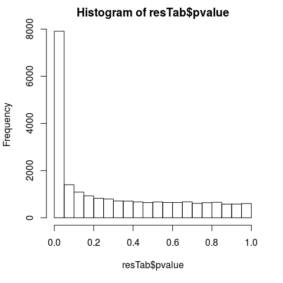

```r
hist(resTab$pvalue)
```

## MA plots

MA plots are a common way to visualize the results of a differential analysis. We met them briefly towards the end of Session 2. This plot shows the log-Fold Change for each gene against its average expression across all samples in the two conditions being contrasted.

`DESeq2` has a handy function for plotting this…

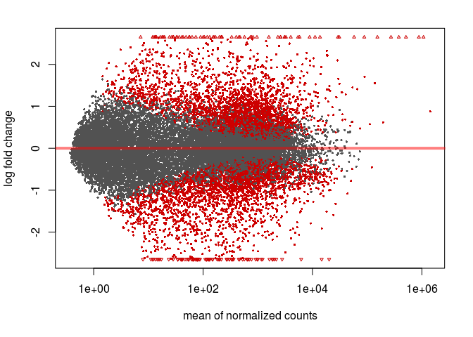

```r
plotMA(ddsShrink, alpha=0.05)
```

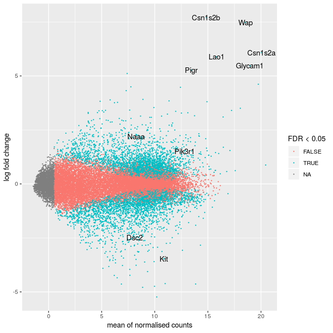

```r
# add a column with the names of only the top 10 genes
cutoff <- sort(resTab$pvalue)[10]
resTab <- resTab %>%
    mutate(TopGeneLabel=ifelse(pvalue<=cutoff, Symbol, ""))
ggplot(resTab, aes(x = log2(baseMean), y=logFC)) +
    geom_point(aes(colour=FDR < 0.05), pch=20, size=0.5) +
    geom_text(aes(label=TopGeneLabel)) +
    labs(x="mean of normalised counts", y="log fold change")
```

## Volcano plot

Another common visualisation is the *volcano plot* which displays a measure of significance on the y-axis and fold-change on the x-axis. In this case we use the log2 fold change (`logFC`) on the x-axis, and on the y-axis we’ll use `-log10(FDR)`. This `-log10` transformation is commonly used for p-values as it means that more significant genes have a higher scale. We should first remove the genes that we excluded by the independent filtering process of DESeq2

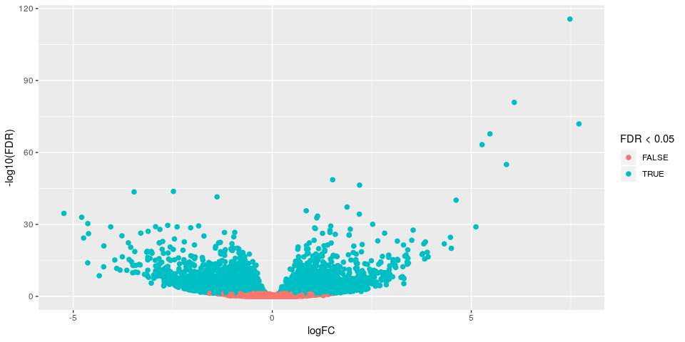

```r
# first remove the filtered genes (FDR=NA) and create a -log10(FDR) column
filtTab <- resTab %>%
    filter(!is.na(FDR)) %>%
    mutate(`-log10(FDR)` = -log10(FDR))
ggplot(filtTab, aes(x = logFC, y=`-log10(FDR)`)) +
    geom_point(aes(colour=FDR < 0.05), size=2)
```

We could limit the values at the top of the plot so that we can see the lower portion more clearly.

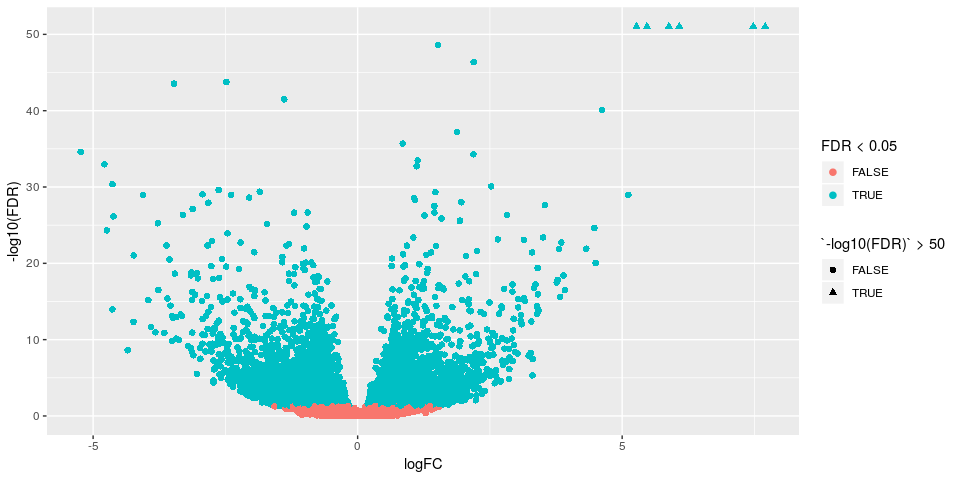

```r
filtTab <- filtTab %>%
    mutate(`-log10(FDR)`=ifelse(`-log10(FDR)` >50, 51, `-log10(FDR)`))
ggplot(filtTab, aes(x = logFC, y=`-log10(FDR)`)) +
    geom_point(aes(colour=FDR < 0.05, shape = `-log10(FDR)` > 50), size=2)
```

### Strip chart for gene expression

Before following up on the DE genes with further lab work, a recommended *sanity check* is to have a look at the expression levels of the individual samples for the genes of interest. We can quickly look at grouped expression using `stripchart`. We can retrieve the normalised expression values in the `ddsObj` object using the `counts` function from DESeq2.

```r
normCounts <- counts(ddsObj, normalized=TRUE) %>%
    log2()
# Let's look at the most significantly differentially expressed gene: Wap
topgene <- filter(resTab, Symbol=="Wap")
topgene
```

| GeneID | baseMean | logFC | lfcSE | stat | pvalue | FDR | Entrez | Symbol | Description | Biotype | Chr | Start | End | Strand | TopGeneLabel |
| --- | --- | --- | --- | --- | --- | --- | --- | --- | --- | --- | --- | --- | --- | --- | --- |
| ENSMUSG00000000381 | 378557.8 | 7.478478 | 0.3496242 | 23.3522 | 1.308924e-120 | 2.490227e-116 | 22373 | Wap | whey acidic protein [Source:MGI Symbol;Acc:MGI:98943] | protein_coding | 11 | 6635482 | 6638637 | -1 | Wap |

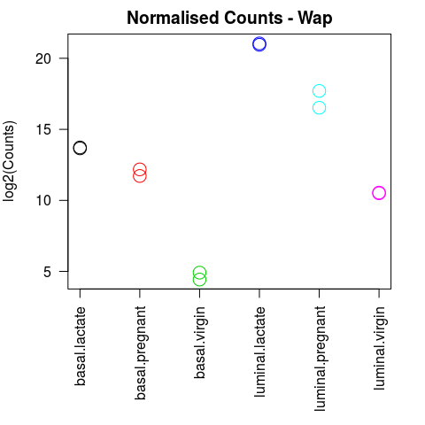

```r
groups <- colData(ddsObj)$Group
par(mar=c(8,4,2,2)) #adjust the plot margins the x-labels are visible - see ?par
stripchart(normCounts["ENSMUSG00000000381",]~groups,
           col=1:6,
           vertical=TRUE,
           pch=21,
           las=2,
           cex=2,
           xlab="",
           ylab="log2(Counts)",
           main="Normalised Counts - Wap")
```

### Interactive StripChart with Glimma

An interactive version of the volcano plot above that includes the raw per sample values in a separate panel is possible via the `glXYPlot` function in the *Glimma* package.

```r
library(Glimma)
group <- as.factor(sampleinfo$Group)
levels(group) <- c("basal.lact","basal.preg","basal.vir",
                   "lum.lact", "lum.preg", "lum.vir")
annot.mod <- filtTab[,c("GeneID", "Symbol", "Description")]
de <- as.numeric(filtTab$FDR<=0.05)
filtCounts <- normCounts[filtTab$GeneID,]
glXYPlot(x=filtTab$logFC, y=-log10(filtTab$FDR),
         xlab="logFC", ylab="FDR", main="Lactating v Virgin",
         counts=filtCounts, groups=group, status=de,
         anno=annot.mod, id.column="ENTREZID", folder="volcano")
```

This function creates an html page (./volcano/XY-Plot.html) with a volcano plot on the left and a plot showing the log-CPM per sample for a selected gene on the right. A search bar is available to search for genes of interest.

## Additional Material

### Retrieving Detailed Genomic Locations

```r
makeTxDbPackageFromBiomart(version="0.99.0",
                           maintainer="Fozzy Bear <FozzyBear@themuppetshow.com>",
                           author="Kermit the Frog <Kermit@themuppetshow.com>",
                           dataset="mmusculus_gene_ensembl")
```

```
Creating package in ./TxDb.Mmusculus.BioMart.ENSEMBLMARTENSEMBL.GRCm38.p6
```

[output not shown]

Accessing the information in these TxDb databases is similar to the way in which we accessed information using `biomaRt` except that `filters` (the information we are filtering on) are now called `keys` and `attributes` (things we want to retrieve) are `columns`.

First we need to decide what information we want. In order to see what we can extract we can run the `columns` function on the annotation database.

```r
columns(txMm)
```

[output not shown]

### Challenge 2

> Use the txMm to retrieve the exon coordinates for the genes: + `ENSMUSG00000021604` + `ENSMUSG00000022146` + `ENSMUSG00000040118`

## Overview of GenomicRanges

One of the real strengths of the `txdb..` databases is the ability to interface with `GenomicRanges`, which is the object type used throughout Bioconductor [to manipulate Genomic Intervals](https://www.ncbi.nlm.nih.gov/pmc/articles/PMC3738458/pdf/pcbi.1003118.pdf).

There are a number of useful functions for calculating properties of the data (such as *coverage* or sorting). Not so much for RNA-seq analysis, but `GenomicRanges` are used throughout Bioconductor for the analysis of NGS data.

### Exporting tracks

It is also possible to save the results of a Bioconductor analysis in a browser to enable interactive analysis and integration with other data types, or sharing with collaborators. For instance, we might want a browser track to indicate where our differentially-expressed genes are located. We shall use the `bed` format to display these locations. We will annotate the ranges with information from our analysis such as the fold-change and significance.

### Scores and colour on exported tracks

The `.bed` file format is commonly used to store genomic locations for display in genome browsers (e.g. the UCSC browser or IGV) as tracks. Rather than just representing the genomic locations, the `.bed` format is also able to colour each range according to some property of the analysis (e.g. direction and magnitude of change) to help highlight particular regions of interest. A score can also be displayed when a particular region is clicked-on.

`colorRampPalette` is a useful function in base R for constructing a palette between two extremes. **When choosing colour palettes, make sure they are colour blind friendly**. The red / green colour scheme traditionally-applied to microarrays is a *bad* choice.

## Extracting Reads

As we have been using counts as our starting point, we haven’t investigated the aligned reads from our experiment, and how they are represented. As you may be aware, aligned reads are usually stored in a *bam* file that can be manipulated with open-source command-line tools such as [*samtools*](http://www.htslib.org/) and [*picard*](https://broadinstitute.github.io/picard/). Bioconductor provide a low-level interface to data/bam/sam files in the form of the `Rsamtools` package. The `GenomicAlignments` package can also be used to retrieve the reads mapping to a particular genomic region in an efficient manner.

In the directory `small_bams` there should be `.bam` files for some of the samples in the example study. The workflow to produce these files is described in a supplmentary page for the course. In brief, the raw reads (`fastq`) were downloaded from the Short Read Archive (SRA) and aligned with `hisat2`. Each bam file was named according to the file name in SRA, but we have renamed the files according to their name in the study. An index file (`.bai`) has been generated for each bam file. In order to reduce the size, the bam files used here only contain a subset of the reads that were aligned in the region chr15:101707000-101713000.

- Read is unmapped
- Read is paired / unpaired
- Read failed QC
- Read is a PCR duplicate (see later)

The combination of any of these properties is used to derive a numeric value, as illustrated in this useful [resource](https://broadinstitute.github.io/picard/explain-flags.html)

However, there are more-sophisticated visualisation options for aligned reads and range data. We will use the `ggbio` package, which first requires some discussion of the `ggplot2` plotting package.

## Composing plots with ggbio

We will now take a brief look at one of the visualisation packages in Bioconductor that takes advantage of the GenomicRanges and GenomicFeatures object-types. In this section we will show a worked example of how to combine several types of genomic data on the same plot. The documentation for ggbio is very extensive and contains lots of examples.

http://www.tengfei.name/ggbio/docs/

The `Gviz` package is another Bioconductor package that specialising in genomic visualisations, but we will not explore this package in the course.

The Manhattan plot is a common way of visualising genome-wide results, especially when one is concerned with the results of a GWAS study and identifying strongly-associated hits.

The profile is supposed to resemble the Manhattan skyline with particular skyscrapers towering about the lower level buildings.

`plotGrandLinear` is a special function in `ggbio` with preset options for the manhattan style of plot. More often, users will call the `autoplot` function and `ggbio` will choose the most appropriate layout. One such layout is the *karyogram*.

```r
autoplot(top200, layout="karyogram", aes(color=UpRegulated,
                                       fill=UpRegulated))
```

[output not shown]

```r
autoplot(txMm, which=exo[["ENSMUSG00000022146"]])
```

[output not shown]

We can even plot the location of sequencing reads if they have been imported using readGAlignments function (or similar).

```r
myreg <- exo[["ENSMUSG00000022146"]] %>%
    GenomicRanges::reduce() %>%
    flank(width = 1000, both = T) %>%
    keepSeqlevels(value = 15, pruning.mode="tidy")

bam <- readGappedReads(file="counts/small_bams/MCL1.DG.15.sm.bam",
                       param=ScanBamParam(which=myreg), use.names = TRUE)

autoplot(bam, geom = "rect") +
    xlim(GRanges("15", IRanges(101707000, 101713000)))
```

[output not shown]

Like ggplot2, ggbio plots can be saved as objects that can later be modified, or combined together to form more complicated plots. If saved in this way, the plot will only be displayed on a plotting device when we query the object. This strategy is useful when we want to add a common element (such as an ideogram) to a plot composition and don’t want to repeat the code to generate the plot every time.

```r
#idPlot <- plotIdeogram(genome = "mm10",subchr = "chr1")
#idPlot
geneMod <- autoplot(tx, which = myreg)
reads.MCL1.DG <- autoplot(bam, stat = "coverage")  +
    xlim(GRanges("chr15", IRanges(101707000, 101713000))) +
    labs(title="MCL1.DG")
tracks(mm10=geneMod, MCL1.DG=reads.MCL1.DG )
```

[output not shown]

## Challenge

> Create tracks to compare the coverage of the gene Krt5 for the samples MCL1.DG, MCL1.DH, MCL1.LA and MCL1.LB